# Calculating tidal levels for MercyHospital

- Show All Code
- Hide All Code
- View Source

Author

Fernando Mayer, Niamh Cahill, Niamh Mimnagh

Published

October 10, 2026

# MercyHospital

## Introduction

The aim of this document is to explore tide-level data from the Marine Institute (MI) and the Office of Public Works (OPW). The final result should be to obtain the tidal levels for each station in Ireland where MI/OPW has available data.

## Data

```r
## Packages
library(arrow)
library(tidyverse)
library(patchwork)
library(TideHarmonics)
here::i_am("index.qmd")
source(here::here("scripts", "_functions.R"))
theme_set(theme_bw() + theme(legend.position = "right", legend.direction = "vertical"))


## Full dataset
fl <- here::here("data", "merged_tide_gauge_data", "iteration_a_qc1")
da <- open_dataset(fl, format="parquet")

## Station-specific start dates
station_start_dates <- c(
  "Inishmore" = "2016-01-01",
  "Sligo" = "2018-01-01",
  "SkerriesHarbour" = "2013-01-01"
)

## Filter for station
db <- da |>
  filter(st_id == params$station) |>
  mutate(year = year(time), .before = "station_id") |>
  mutate(QC_Flag = NULL, sea_level = Water_Level_OD_Malin, Water_Level_OD_Malin = NULL) |>
  arrange(time) |>
  collect()

## Apply station-specific start date where required
if (params$station %in% names(station_start_dates)) {
  db <- db |>
    filter(time >= as.POSIXct(station_start_dates[[params$station]], tz = "UTC"))
}


## Save the name for posterior use
station_id <- unique(db$station_id)
st_id <- gsub(" ", "", station_id)
## Save lat/lon for posterior use
lat <- unique(db$latitude)
lon <- unique(db$longitude)

## Check dates
dtab <- db |> summarise(dmin = min(time), dmax = max(time))



## Length of the actual available record

record_start <- min(db$time, na.rm = TRUE)
record_end   <- max(db$time, na.rm = TRUE)

record_days <- as.numeric(difftime(record_end, record_start, units = "days"))

record_years <- record_days / 365.25

## Minimum record length used in the tidal analysis
MIN_RECORD_YEARS <- 3
```

This document examines the data for MercyHospital, where:

- The total number of observations is 109986
- The first observation was recorded on 2021-11-03 16:00:00
- The last observation was recorded on 2024-12-31 23:45:00

The figure below shows the number of observations per year.

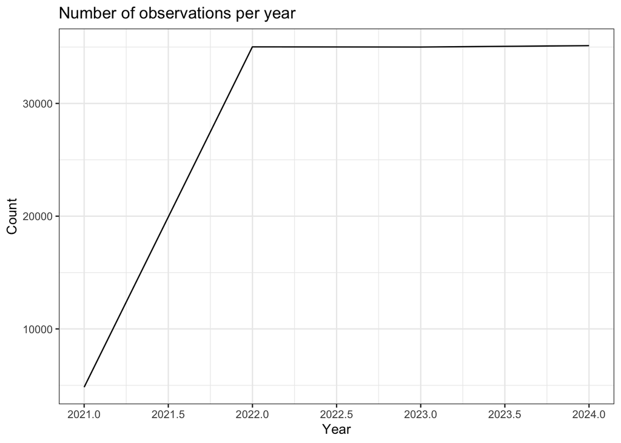

```r
## Count time series
db |>
    count(year) |>
    ggplot(aes(x = year, y = n)) +
    geom_line() +
    scale_x_continuous(breaks = scales::pretty_breaks(n = 10)) +
    labs(x = "Year", y = "Count", title = "Number of observations per year")
```

The full dataset is shown in the first panel below, while the second panel shows a random monthly variation, to check the tidal variability.

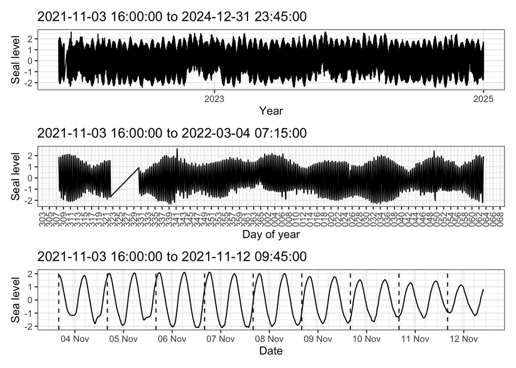

```r
## Full range
p1 <- db |>
    ggplot(aes(time, sea_level)) +
    geom_line() +
    scale_x_datetime(date_breaks = "2 years", date_minor_breaks = "1 year", date_labels = "%Y") +
    labs(title = sprintf("%s to %s", dtab$dmin, dtab$dmax), x = "Year", y = "Seal level")

dtab <- dtab |>
    mutate(smin = db |> slice_head(n = 5 * 90 * 24) |> pull(time) |> min(), smax = db |> slice_head(n = 5 * 90 * 24) |> pull(time) |> max())

p2 <- db |>
    filter(time >= dtab$smin, time <= dtab$smax) |>
    ggplot(aes(time, sea_level)) +
    geom_line() +
    scale_x_datetime(date_breaks = "2 days", date_minor_breaks = "1 day", date_labels = "%j") +
    labs(title = sprintf("%s to %s", dtab$smin, dtab$smax), x = "Day of year", y = "Seal level") +
    theme(axis.text.x = element_text(angle = 90, vjust = 0.5))

dtab <- dtab |>
    mutate(hmin = db |> slice_head(n = 5 * 7 * 24) |> pull(time) |> min(), hmax = db |> slice_head(n = 5 * 7 * 24) |> pull(time) |> max())

p3 <- db |>
    filter(time >= dtab$hmin, time <= dtab$hmax) |>
    ggplot(aes(x = time, y = sea_level)) +
    geom_line() +
    geom_vline(xintercept = seq(dtab$hmin, dtab$hmax, by = "day"), linetype = "dashed") +
    scale_x_datetime(date_breaks = "1 day", date_minor_breaks = "6 hours", date_labels = "%d %b") +
    labs(title = sprintf("%s to %s", dtab$hmin, dtab$hmax), x = "Date", y = "Sea level") +
    theme(axis.text.x = element_text(angle = 0, hjust = 0.5))
p1/p2/p3
```

The following graphs shows the general trend of MSL, minima and maxima for the full dataset, as well as the distribution of all the observed values.

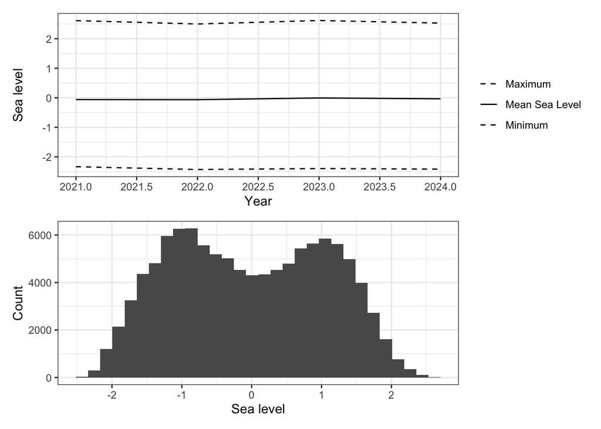

```r
## Get a rough view of variations
p1 <- db |>
    group_by(year) |>
    summarise(max = max(sea_level), msl = mean(sea_level), min = min(sea_level)) |>
    pivot_longer(cols = c(max, msl, min), names_to = "stat", values_to = "sea_level") |>
    ggplot(aes(x = year, y = sea_level, linetype = stat)) +
    geom_line() +
    scale_linetype_manual(
        values = c("max" = "dashed", "msl" = "solid", "min" = "dashed"),
        breaks = c("max", "msl", "min"),
        labels = c("max" = "Maximum", "msl" = "Mean Sea Level", "min" = "Minimum")) +
    scale_x_continuous(breaks = scales::pretty_breaks(n = 10)) +
    labs(x = "Year", y = "Sea level", linetype = "")

p2 <- db |>
    ggplot() +
    geom_histogram(aes(x = sea_level)) +
    labs(x = "Sea level", y = "Count")
p1/p2
```

To check the sample interval, all the differences between two consecutive times were calculated, and the number of such intervals is shown below.

```r
## Time difference between observations
## In minutes
db <- db |> mutate(dtime = as.numeric(difftime(time, lag(time), units = "mins")))

## Check the dominant sample interval
db |> count(dtime) |>
    mutate(prop = n/sum(n)) |>
    arrange(desc(n)) |>
    head() |>
    knitr::kable(digits = 3) |>
    kableExtra::kable_styling(font_size = 8)
db |> count(dtime) |>
    mutate(prop = n/sum(n)) |>
    arrange(desc(n)) |>
    tail() |>
    knitr::kable(digits = 3) |>
    kableExtra::kable_styling(font_size = 8)
```

First 6 lines {#tbl-anonymous-8070442-1}

| dtime | n | prop |
| --- | --- | --- |
| 15 | 109955 | 1 |
| 30 | 19 | 0 |
| 45 | 5 | 0 |
| 60 | 1 | 0 |
| 90 | 1 | 0 |
| 105 | 1 | 0 |

Last 6 lines {#tbl-anonymous-8070442-2}

| dtime | n | prop |
| --- | --- | --- |
| 90 | 1 | 0 |
| 105 | 1 | 0 |
| 135 | 1 | 0 |
| 270 | 1 | 0 |
| 11445 | 1 | 0 |
| NA | 1 | 0 |

```r
## This is the sampling time, completed and standardised to 10 minutes
db_comp <- db |>
    select(-c(year, dtime)) |>
    mutate(time_rounded = floor_date(time, "10 min")) |>
    complete(time_rounded = seq(min(time_rounded), max(time_rounded), by = "10 min")) |>
    group_by(time_rounded) |>
    summarise(
        sea_level = mean(sea_level, na.rm = TRUE),
        n_obs = n(),
        n_na = sum(is.na(sea_level)),
        .groups = "drop"
    ) |>
    rename(time = time_rounded) |>
    distinct(time, .keep_all = TRUE) |>
    arrange(time) |>
    mutate(
        sea_level = ifelse(is.nan(sea_level), NA_real_, sea_level),
        dtime = as.numeric(difftime(time, lag(time), units = "mins"))
    )

## Define the period to use for the tidal analysis
##
## Stations must have at least 3 years of data to be included.
## Stations with less than 3 years are excluded.

if (record_years < 3) {
    stop(sprintf("%s has only %.2f years of data and is excluded from the tidal analysis.", st_id, record_years))
}

## Identify complete calendar years

complete_years <- db_comp |>
    mutate(year = year(time), month = month(time)) |>
    group_by(year) |>
    summarise(
        min_month = min(month),
        max_month = max(month),
        n_months = n_distinct(month),
        .groups = "drop"
    ) |>
    filter(min_month == 1, max_month == 12, n_months == 12) |>
    arrange(year)

## Check that at least one complete calendar year exists
if (nrow(complete_years) == 0) {
    stop(sprintf("%s has no complete calendar years available for tidal analysis.", st_id))
}

## First and last complete calendar years
year_first <- min(complete_years$year)
year_last <- max(complete_years$year)
year_all <- year_first:year_last



## Check that the complete-year analysis period contains at least 3 years

if (length(year_all) < 3) {
    stop(sprintf(paste0("%s has %.2f years of raw data, but fewer than 3 complete ", "calendar years are available after restricting the analysis period."), st_id, record_years))
}



## Restrict to complete-year period
db_comp <- db_comp |>
    filter(year(time) >= year_first, year(time) <= year_last) |>
    arrange(time)

dtab_comp <- db_comp |>
    summarise(dmin = min(time), dmax = max(time))
```

To standardise the sample interval, a sampling interval is defined, and all the data was adjuted to fit between this interval.

This was determined using the first and last “full years” of the dataset, i.e., the first and final years where data is available for all the 12 months. In this case, the first full year is 2022, and the last full year is 2024, giving in total a range of 3 years.

- The first observation is on 2022-01-01
- The last observation is on 2024-12-31 23:40:00

## Model

### Model fit

```r
## Create the fitting windows
k <- c(3, 5, length(year_all))

## Avoid duplicate intervals
##
## For example, if there are exactly 5 years available then:
## 5-year window == full-record window so only one copy is retained.
k <- unique(k)

## Create rolling windows
seq <- map(k, \(x) seq_win(year_all, k = x, step = 1))

names(seq) <- sprintf("y_%s", k)



## Name individual year windows
for (i in seq_along(seq)) {

    names(seq[[i]]) <- sprintf("y%s_%s", sapply(seq[[i]], \(x) max(x)), sapply(seq[[i]], \(x) min(x)))
}



## Display fitting windows as a tidy table

window_table <- imap_dfr(seq, \(window_list, window_name) {
        imap_dfr(window_list, \(years, window_id) {
                tibble(
                    window_size = window_name,
                    year_range = window_id,
                    first_year = min(years),
                    last_year = max(years),
                    n_years = length(years))
            }
        )
    }
)

window_table |>
  select(window_size, first_year, last_year) |>
  knitr::kable(col.names = c("Window size (years)", "Beginning year", "Last year"),
    caption = "Time windows used for tidal harmonic analysis") |>
  kableExtra::kable_styling(font_size = 9, full_width = FALSE)
```

Time windows used for tidal harmonic analysis

| Window size (years) | Beginning year | Last year |
| --- | --- | --- |
| y_3 | 2022 | 2024 |

```r
## Check that each proposed window contains usable observations
## Some stations may span several calendar years but contain little or no
## usable sea-level data within an individual rolling window. Remove such
## windows before fitting the TideHarmonics model.

seq_checked <- vector(mode = "list", length = length(seq))
names(seq_checked) <- names(seq)


for (i in seq_along(seq)) {
    valid_windows <- list()
    for (j in seq_along(seq[[i]])) {
        n1 <- names(seq)[[i]]
        n2 <- names(seq[[i]])[[j]]

        ## Define calendar-year limits for this window
        t1 <- make_datetime(year = min(seq[[i]][[j]]))
        t2 <- make_datetime(year = max(seq[[i]][[j]]), month = 12, day = 31, hour = 23, min = 50)

        ## Extract data for this window
        db_window <- db_comp |>
            filter(time >= t1, time <= t2)

        ## Count usable sea-level observations
        n_non_na <- sum(!is.na(db_window$sea_level))

        ## Keep only windows containing usable observations
        if (n_non_na > 0) {
            valid_windows[[n2]] <- seq[[i]][[j]]
        }
    }

    ## Store valid windows for this window size
    seq_checked[[i]] <- valid_windows
}



## Remove window-size groups containing no valid windows
seq <- seq_checked[lengths(seq_checked) > 0]


## Stop if no usable windows remain
if (length(seq) == 0) {
    stop(sprintf("No usable tidal-analysis windows remain for station %s.", st_id))
}

## Create a list to hold model results
res <- vector(mode = "list",length = length(seq))
names(res) <- names(seq)


for (i in seq_along(res)) {
    res[[i]] <- vector(mode = "list", length = length(seq[[i]]))
    names(res[[i]]) <- names(seq[[i]])
}



## Fit all valid windows
for (i in seq_along(res)) {
    for (j in seq_along(res[[i]])) {

        n1 <- names(seq)[[i]]
        n2 <- names(seq[[i]])[[j]]

        ## Define calendar-year limits
        t1 <- make_datetime(year = min(seq[[i]][[j]]))
        t2 <- make_datetime(year = max(seq[[i]][[j]]), month = 12, day = 31, hour = 23, min = 50)

        ## Extract data for this fitting window
        db_window <- db_comp |>
            filter(time >= t1, time <= t2)

        ## Model file
        fl <- here::here("rds", sprintf("fit-%s-%s-%s.rds", n1, n2, st_id))

        ## Fit model if it has not already been saved
        if (!file.exists(fl)) {
            res[[i]][[j]] <- fit_th(x = db_window$sea_level, dto = db_window$time, pred = FALSE)
            saveRDS(res[[i]][[j]], fl)

        } else {
           res[[i]][[j]] <- readRDS(fl)
        }
    }
}
```

### Model results

#### Tidal constituents

K1, O1, M2, and S2 are the main tidal constituents because they represent the dominant astronomical forcing mechanisms and typically have the largest amplitudes.

- Semi-diurnal constituents (2 cycles per day):
  - **M2** (Principal lunar semi-diurnal): The largest tidal constituent in most places. Period = 12.42 hours. Caused by the moon’s gravitational pull as Earth rotates beneath it.
  - **S2** (Principal solar semi-diurnal): Second largest semi-diurnal constituent. Period = 12.00 hours. Caused by the sun’s gravitational pull.
- Diurnal constituents (1 cycle per day):
  - **K1** (Lunisolar diurnal): Largest diurnal constituent. Period = 23.93 hours. Results from the declination of the moon and sun.
  - **O1** (Principal lunar diurnal): Second largest diurnal constituent. Period = 25.82 hours. Due to lunar declination effects.

Why these four matters:

1. **Largest amplitudes**: They typically account for 70-90% of tidal variance
2. **Physical significance**:
   - M2 & S2 create spring-neap cycles (14-day variation)
   - K1 & O1 create diurnal inequality (different heights of successive high/low tides)
3. **Tidal classification**: The form factor (K1+O1)/(M2+S2) uses these to classify whether tides are semi-diurnal, diurnal, or mixed
4. **Coastal features**: MHWS, MLWS, etc. are primarily defined by M2 and S2

```r
## Extract constituent amplitudes
constituent_amps <- map(res, \(x) map(x, \(y) {
  coefs <- y$coefficients
  tibble(
    K1 = sqrt(coefs["K1_C"]^2 + coefs["K1_S"]^2),
    O1 = sqrt(coefs["O1_C"]^2 + coefs["O1_S"]^2),
    M2 = sqrt(coefs["M2_C"]^2 + coefs["M2_S"]^2),
    S2 = sqrt(coefs["S2_C"]^2 + coefs["S2_S"]^2)
  )
})) |>
  imap_dfr(function(window_list, window_name) {
    imap_dfr(window_list, function(amps, year_range) {
      amps |>
        mutate(window_size = window_name, year_range = year_range, .before = 1)
    })
  }) |>
  mutate(
    n_years = as.integer(str_extract(window_size, "\\d+")),
    year_end = as.integer(str_extract(year_range, "(?<=y)\\d+")),
    year_start = as.integer(str_extract(year_range, "\\d+$")),
    year_mid = (year_start + year_end) / 2
  ) |>
  pivot_longer(cols = c(K1, O1, M2, S2), names_to = "constituent", values_to = "amplitude")

## Plot
## Extract the last window size as the full-record reference
ly <- constituent_amps$window_size |> tail(1)

amps_ref <- constituent_amps |>
    filter(window_size == ly) |>
    select(constituent, amplitude)

## Create better labels for window_size
window_labels <- c("y_3" = "3 years range",  "y_5" = "5 years range")

## Data used for rolling-window comparison
plot_data <- constituent_amps |>
    filter(window_size != ly)

## Plot only when there is at least one rolling window available
if (nrow(plot_data) > 0) {

    plot_data |>
        ggplot(aes(x = make_datetime(year_mid), y = amplitude)) +
        geom_hline(data = amps_ref, aes(yintercept = amplitude, linetype = "Full dataset"), color = "red", alpha = 0.7) +
        geom_line() +
        geom_point() +
        facet_grid(constituent ~ window_size, scales = "free_y", labeller = labeller(window_size = window_labels)) +
        scale_x_datetime(date_breaks = "2 year", date_minor_breaks = "1 year", date_labels = "%Y") +
        scale_linetype_manual(name = "Reference", values = c("Full dataset" = "dashed")) +
        labs(x = "Midpoint Year", y = "Amplitude (m)", title = "Tidal Constituent Amplitudes Over Time")

} else {

    cat("Only one analysis window is available for this station. ", "A rolling-window comparison plot is therefore not shown.")
}
```

```
#| Only one analysis window is available for this station.  A rolling-window comparison plot is therefore not shown.
```

#### Form factor

The form factor is calculated by

$$(K1+O1)/(M2+S2)$$

and it classifies tides as:

- < 0.25: Semi-diurnal
- 0.25-1.5: Mixed, mainly semi-diurnal
- 1.5-3.0: Mixed, mainly diurnal
- > 3.0: Diurnal

```r
fval_data <- map(res, \(x) map(x, \(y) y$fval)) |>
    imap_dfr(function(window_list, window_name) {
        imap_dfr(window_list, function(fval, year_range) {
            tibble(window_size = window_name, year_range = year_range, fval = fval)
        })
    }) |>
    mutate(
        # Extract numeric window size (3, 5, 16)
        n_years = as.integer(str_extract(window_size, "\\d+")),
        # Extract years from "y2023_2021" format
        year_end = as.integer(str_extract(year_range, "(?<=y)\\d+")),
        year_start = as.integer(str_extract(year_range, "\\d+$")),
        # Calculate midpoint year for plotting
        year_mid = (year_start + year_end) / 2
    )

## Plot
## Get reference value
fval_ref <- fval_data |>
    filter(window_size == ly) |>
    pull(fval)

## Data used for rolling-window comparison
fval_plot_data <- fval_data |>
    filter(window_size != ly)

## Plot only when at least one comparison window is available
if (nrow(fval_plot_data) > 0) {

    ## The full-record reference should be a single value
    fval_ref <- fval_ref[1]

fval_plot_data |>
    ggplot(aes(x = make_datetime(year_mid), y = fval)) +
    geom_hline(yintercept = fval_ref, aes(linetype = "Full dataset"), color = "red") +
    geom_line() +
    geom_point() +
    facet_wrap(~ window_size, labeller = labeller(window_size = window_labels)) +
    scale_x_datetime(date_breaks = "2 years", date_minor_breaks = "1 year",
        date_labels = "%Y", guide = guide_axis(angle = 45)) +
    scale_linetype_manual(name = "Reference", values = c("Full dataset" = "dashed")) +
    labs(x = "Midpoint Year", y = "Form factor",
        title = "Tidal Harmonic Model form factors") +
    theme(axis.text.x = element_text(size = 8))

} else {

    cat("Only one analysis window is available for this station. ", "A rolling-window form-factor comparison plot is therefore not shown.")
}
```

```
#| Only one analysis window is available for this station.  A rolling-window form-factor comparison plot is therefore not shown.
```

#### Tidal levels

Tidal levels (or features) are defined as:

- **HAT** (Highest Astronomical Tide) = maximum predicted astronomical tide over the reference prediction period
- **MSL** (Mean Sea Level) = mean of the time series (or the constant/mean term in the model)
- **MHWS** (Mean High Water Springs) = MSL + M2_amp + S2_amp
- **MHWN** (Mean High Water Neaps) = MSL + M2_amp - S2_amp
- **MLWN** (Mean Low Water Neaps) = MSL - M2_amp + S2_amp
- **MLWS** (Mean Low Water Springs) = MSL - M2_amp - S2_amp
- **LAT** (Lowest Astronomical Tide) = minimum predicted astronomical tide over the reference prediction period

Where:

- **M2** = principal lunar semi-diurnal (largest constituent)
- **S2** = principal solar semi-diurnal

Springs occur when M2 and S2 are in phase (add together), creating the highest highs and lowest lows.

Neaps occur when M2 and S2 are out of phase (subtract), creating smaller tidal ranges.

```r
hat_lat_data <- imap_dfr(res, function(window_list, window_name) {
    imap_dfr(window_list, function(fit, year_range) {
        lat_hat_file <- here::here("rds", "lat-hat", sprintf("lat-hat-%s-%s-%s.rds", window_name, year_range, st_id))
        ## Default: no calculation failure
        lat_hat_error <- NA_character_

        ## Read existing result or calculate a new one

        if (file.exists(lat_hat_file)) {
            lat_hat <- readRDS(lat_hat_file)
        } else {
            lat_hat <- tryCatch(calculate_lat_hat(fit = fit), error = function(e) {
                    lat_hat_error <<- conditionMessage(e)
                    cat(sprintf(paste0("WARNING: LAT/HAT calculation failed for ", "%s | %s | %s\n", "Reason: %s\n"),
                            st_id, window_name, year_range, lat_hat_error))

                    tibble(constituent = c("LAT", "HAT"), value = c(NA_real_, NA_real_))
                }
            )
        }


        ## Check HAT/LAT values
        ##
        ## This is deliberately a very generous threshold. It is intended only
        ## to identify catastrophic numerical/extrapolation failures such as
        ## HAT/LAT values of hundreds or millions of metres.
        ##
        ## It should not affect plausible tidal estimates.

        MAX_ABS_TIDAL_LEVEL <- 20
        lat_value <- lat_hat |>
            filter(constituent == "LAT") |>
            pull(value)
        hat_value <- lat_hat |>
            filter(constituent == "HAT") |>
            pull(value)

        ## Determine whether the calculated values are numerically plausible
        invalid_lat_hat <- FALSE
        if (length(lat_value) != 1L || length(hat_value) != 1L) {
            invalid_lat_hat <- TRUE
            lat_hat_error <- paste0("LAT/HAT calculation returned an unexpected number of values.")

        } else if (!is.finite(lat_value) || !is.finite(hat_value)) {
            invalid_lat_hat <- TRUE
            lat_hat_error <- paste0("LAT/HAT calculation returned non-finite values.")

        } else if (abs(lat_value) > MAX_ABS_TIDAL_LEVEL || abs(hat_value) > MAX_ABS_TIDAL_LEVEL) {
            invalid_lat_hat <- TRUE
            lat_hat_error <- sprintf(paste0("Numerically implausible LAT/HAT values detected ", "(LAT = %.3f m, HAT = %.3f m)."),  lat_value, hat_value)

        } else if (lat_value >= hat_value) {
            invalid_lat_hat <- TRUE
            lat_hat_error <- sprintf(paste0("Invalid LAT/HAT ordering ", "(LAT = %.3f m, HAT = %.3f m)."), lat_value, hat_value)
        }

        ## If the LAT/HAT values are invalid, replace them with NA
        ## The tidal harmonic fit itself is retained. Only the unreliable
        ## astronomical extremes are removed.
        if (invalid_lat_hat) {
            cat(sprintf(paste0("WARNING: Rejecting LAT/HAT for ", "%s | %s | %s\n", "Reason: %s\n"),
                    st_id, window_name, year_range, lat_hat_error))
            lat_hat <- lat_hat |>
                mutate(value = NA_real_)

        } else {
            ## Save only valid LAT/HAT calculations
            if (!file.exists(lat_hat_file)) {
                saveRDS(lat_hat, lat_hat_file)
            }
        }

        ## Format output
        lat_hat |>
            select(constituent, value) |>
            mutate(window_size = window_name, year_range = year_range, lat_hat_error = lat_hat_error, .before = 1)
    })
}) |>
    mutate(n_years = as.integer(str_extract(window_size, "\\d+")),
        year_end = as.integer(str_extract(year_range, "(?<=y)\\d+")),
        year_start = as.integer(str_extract(year_range,"\\d+$")),
        year_mid = (year_start + year_end) / 2,

        ##  Skerries exclusion
        value = if_else(
            params$station == "SkerriesHarbour" &
                window_size == "y_3" &
                year_start == 2010L &
                year_end == 2012L,
            NA_real_,
            value),

        ##  Inishmore exclusion
        value = if_else(
            params$station == "Inishmore" &
                window_size == "y_3" &
                year_start == 2015L &
                year_end == 2017L,
            NA_real_,
            value
        ),

        ## Record why values are missing
        exclusion_reason = case_when(
            params$station == "SkerriesHarbour" &
                window_size == "y_3" &
                year_start == 2010L &
                year_end == 2012L ~ "Insufficient observations in the 2010-2012 rolling window",

            !is.na(lat_hat_error) ~  paste0( "HAT/LAT excluded: ", lat_hat_error),TRUE ~NA_character_))

features1_data <- map(res, \(x) map(x, \(y) y$features1)) |>
    imap_dfr(function(window_list, window_name) {
        imap_dfr(window_list, function(features1_mat, year_range) {
            as_tibble(features1_mat, rownames = "constituent") |>
                mutate(window_size = window_name, year_range = year_range, .before = 1)
        })
    }) |>
    mutate(n_years = as.integer(str_extract(window_size, "\\d+")),
        ## Extract years
        year_end = as.integer(str_extract(year_range, "(?<=y)\\d+")),
        year_start = as.integer(str_extract(year_range, "\\d+$")),
        year_mid = (year_start + year_end) / 2,
        constituent = factor(constituent, levels = c("MHWS", "MHWN", "MSL", "MLWN", "MLWS")),

        ## Flag implausible tidal levels
        ## Values outside +/- 8 m are treated as failed harmonic estimates.
        implausible_value = !is.na(value) & abs(value) > 8,

        ## Remove unreliable values
        value = case_when(
            ## Keep existing Skerries exclusion
            params$station == "SkerriesHarbour" &
                window_size == "y_3" &
                year_start == 2010L &
                year_end == 2012L ~
                NA_real_,

            ## General plausibility filter
            implausible_value ~ NA_real_, TRUE ~ value),


        ## Record reason for exclusion
        exclusion_reason = case_when(
            params$station == "SkerriesHarbour" &
                window_size == "y_3" &
                year_start == 2010L &
                year_end == 2012L ~
                "Insufficient observations in the 2010-2012 rolling window",

            implausible_value ~  "Implausible tidal-level estimate outside +/- 6 m", TRUE ~  NA_character_))

## Add HAT and LAT to the existing tidal features
features1_data <- bind_rows(features1_data, hat_lat_data) |>
    mutate(constituent = factor(constituent, levels = c("HAT", "MHWS", "MHWN", "MSL", "MLWN", "MLWS", "LAT")))


## Plot
## Extract the full-record/reference values
features1_ref <- features1_data |>
    filter(window_size == ly) |>
    select(constituent, value)

## Data used for the rolling-window comparison
features1_plot_data <- features1_data |>
    filter(window_size != ly)

## Only make the comparison plot when at least one
## non-reference window is available
if (nrow(features1_plot_data) > 0) {
    features1_plot_data |>
        ggplot(aes(x = make_datetime(year_mid), y = value)) +
        geom_hline(data = features1_ref, aes(yintercept = value, linetype = "Full dataset"), color = "red") +
        geom_line() +
        geom_point(size = 1, color = 2) +
        facet_grid(constituent ~ window_size, scales = "free_y", labeller = labeller(window_size = window_labels)) +
        scale_x_datetime(date_breaks = "4 years", date_minor_breaks = "1 year", date_labels = "%Y") +
        scale_linetype_manual(name = "Reference", values = c("Full dataset" = "dashed")) +
        labs(x = "Year", y = "Sea level", title = "Tidal features over years") +
        theme(axis.text.x = element_text(angle = 45, hjust = 1, size = 8))
} else {
    cat("Only one analysis window is available for this station. ", "A rolling-window plot cannot be produced.")
}
```

```
#| Only one analysis window is available for this station.  A rolling-window plot cannot be produced.
```

The table below shows the actual values.

```r
features1_data |>
    select(n_years, year_end, year_start, constituent, value) |>
    pivot_wider(names_from = constituent, values_from = value) |>
    arrange(n_years, desc(year_end)) |>
    knitr::kable(digits = 3, caption = "Tidal Constituents by Window Size and Year Range") |>
    kableExtra::kable_styling(font_size = 8)
```

Tidal Constituents by Window Size and Year Range

| n_years | year_end | year_start | MLWS | MLWN | MSL | MHWN | MHWS | LAT | HAT |
| --- | --- | --- | --- | --- | --- | --- | --- | --- | --- |
| 3 | 2024 | 2022 | -1.921 | -1.024 | -0.035 | 0.955 | 1.851 | -2.228 | 2.445 |

```r
## Before exporting, add st_id, lat and lon for future reference
features1_data <- features1_data |>
    mutate(st_id = st_id, lat = lat, lon = lon)

st_id_file <- st_id |> gsub("['().]", "", x = _)

fl <- here::here("rds", sprintf("features-%s.rds", st_id_file))

saveRDS(features1_data, fl)
```